# Maximum likelihood estimation

Author

Maciej Beręsewicz

## 1 Setup

**R**

There is no need to install or load packages. All functionalities are build in. One may consider installing `maxLik` package or `rootSolve`

```r
install.packages(c("maxLik", "rootSolve"))
```

```r
library(maxLik)
library(rootSolve)
```

**Python**

Load modules

```python
import scipy.stats as st
import numpy as np
import pandas as pd
from scipy.optimize import minimize
from scipy.optimize import fsolve ## finding root(s) of a function -- for scalar parameter
```

**Julia**

Install modules

```julia
using Pkg
Pkg.add(["Optim", "Roots"])
```

Load packages

```julia
using Distributions
using DataFrames
using Random
using Optim
using Roots
```

## 2 Exercise – zero-truncated Poisson distribution

We start with likelihood function

$$L = \prod_i \frac{\lambda^x_i}{(e^\lambda-1)x_i!},$$

then we compute log-likelihood

$$\log L = \sum_i x_i \log \lambda - \sum_i \log(e^\lambda-1) - \sum_i \log(x_i!)$$

In order to get estimate of $\lambda$ we need to calculate derivatives with respect to this parameter. Thus, gradient is given by

$$\frac{\partial \log L}{\partial \lambda} = \frac{\sum_i x_i}{\lambda} - \frac{n e^\lambda}{e^\lambda - 1} =
\frac{\sum_i x_i}{\lambda} - n \frac{e^\lambda}{e^\lambda - 1}.$$

We can also calculate second derivative (hessian)

$$\frac{\partial^2 \log L}{\partial \lambda^2} = - \frac{\sum_i x_i}{\lambda^2} + n \frac{e^\lambda}{(e^\lambda-1)^2}.$$

**R**

### 2.1 Functions and data

Functions

```r
ll <- function(par, x) {
  m <- sum(x)*log(par)-length(x)*log(exp(par)-1)
  m
}

ll_min <- function(par, x) {
  m <- sum(x)*log(par)-length(x)*log(exp(par)-1)
  -m
}

## gradient
grad <- function(par, x)  {
  g <- sum(x) / par - length(x)*exp(par)/(exp(par)-1)
  g
}


## hessian
hess <- function(par, x) {
  h <- -sum(x)/par^2 + length(x)*exp(par)/(exp(par)-1)^2
  h
}

## using pdf

pdf_ztpois <- function(lambda, x) {
    pdfztpoiss <- dpois(x, lambda)/(1-dpois(0, lambda))
    return(-sum(log(pdfztpoiss)))
}
```

Data

```r
d <-  c(1645,183,37, 13,1,1)
x <- rep(1:6,d)
```

### 2.2 Solutions based on log-likelihood function

Solution using `stats::optim` – minimization by default

**Code and result**

```r
optim(par = 1, fn = ll_min, x = x, method = "Brent", lower = 0, upper = 6, hessian = T)
```

```
$par
[1] 0.3086189

$value
[1] 656.1294

$counts
function gradient
      NA       NA

$convergence
[1] 0

$message
NULL

$hessian
         [,1]
[1,] 3358.237
```

```r
optim(par = 1, fn = ll_min, gr = grad, x = x, method = "Brent", lower = 0, upper = 6, hessian = T)
```

```
$par
[1] 0.3086189

$value
[1] 656.1294

$counts
function gradient
      NA       NA

$convergence
[1] 0

$message
NULL

$hessian
          [,1]
[1,] -3358.203
```

```r
optim(par = 1, fn = pdf_ztpois,  x = x, method = "Brent", lower = 0, upper = 6, hessian = T)
```

```
$par
[1] 0.308619

$value
[1] 901.9519

$counts
function gradient
      NA       NA

$convergence
[1] 0

$message
NULL

$hessian
         [,1]
[1,] 3358.236
```

**LLMs (Claude 3.7 Sonnet)**

**Prompt**

```
provide interpretation of the results
```

I’ll provide an interpretation of the `stats::optim` optimization result you’ve shared.

This result shows the output of an optimization procedure where you’re minimizing a negative log-likelihood function (`ll_min`) for some statistical model:

1. **Parameter Estimate (`$par`)**: The optimization found that `0.3086189` is the optimal value for the parameter you were estimating.
2. **Minimum Value (`$value`)**: At this parameter value, the objective function (`ll_min`) equals `656.1294`. Since this appears to be a negative log-likelihood minimization, this represents the minimum negative log-likelihood.
3. **Counts**: The `NA` values indicate that the function doesn’t report how many function or gradient evaluations were used.
4. **Convergence (`$convergence = 0`)**: A value of 0 means the optimization algorithm successfully converged to a solution.
5. **Message**: The `NULL` message further confirms there were no issues with convergence.
6. **Hessian (`$hessian`)**: The value `3358.237` is the second derivative of your objective function at the minimum. The large positive value indicates:
   - The solution is a true minimum (not a maximum or saddle point)
   - The curvature is steep, suggesting the parameter estimate is quite precise

The method used was “Brent”, which is appropriate for one-dimensional optimization problems with bounds. You constrained the parameter to be between 0 and 6.

In summary, you’ve successfully estimated a parameter with value approximately 0.31, which minimizes your objective function. The optimization converged properly, and the large Hessian value suggests high confidence in this estimate.

**Prompt**

```
How do you know if this was successful?
```

Based on the output you shared, there are several indicators that the optimization was successful:

1. **Convergence code = 0**: The `$convergence` value of 0 is the primary signal of success. In `optim()`, a convergence value of 0 explicitly means the algorithm converged successfully. Any other value would indicate some type of failure or issue.
2. **No error message**: The `$message` is NULL, meaning the optimizer didn’t encounter any problems worth reporting. If there had been issues with convergence, boundary constraints, or other problems, there would typically be a message explaining the issue.
3. **Positive definite Hessian**: The Hessian value (3358.237) is large and positive, indicating you’ve found a well-defined minimum. This suggests the parameter estimate is stable and the optimization surface has a clear “bowl” shape at that point.
4. **Parameter within bounds**: Your optimal value (0.3086189) falls well within your specified bounds (0 to 6), meaning the solution wasn’t artificially constrained by your boundary conditions.
5. **Reasonable function value**: While this depends on your specific problem, the function value of 656.1294 appears to be a reasonable value for a negative log-likelihood in many statistical applications.

If you want to further verify the success, you could: - Perform multiple optimizations from different starting points to confirm they converge to the same value - Plot the objective function around the minimum to visually confirm the convergence - Calculate the standard error from the Hessian ($SE = 1/\sqrt{Hessian}$) to assess parameter precision

**LLMs (Grok)**

**Prompt**

```
provide interpretation of the results
```

The output you’ve provided appears to be from an optimization process in R, likely from a function like `optim()` or a similar statistical modeling routine. Let’s break it down step-by-step to interpret what it means:

### 2.3 Components of the Output

1. **`$par`**: `[1] 0.3086189`
   - This represents the parameter estimate(s) at which the optimization converged. In this case, it seems to be a single parameter with a value of approximately `0.309`. This could be a coefficient, rate, or some other optimized value depending on the model or function being used.
2. **`$value`**: `[1] 656.1294`
   - This is the value of the objective function (e.g., log-likelihood, sum of squares, or cost function) at the optimized parameter(s). For example, if this is from a maximum likelihood estimation, `656.1294` might be the maximized log-likelihood value. A lower or higher value doesn’t inherently mean “better” unless you know the context (e.g., minimizing vs. maximizing).
3. **`$counts`**:

   ```
   function gradient
         NA       NA
   ```

   - This shows the number of times the objective function and its gradient were evaluated during the optimization process. Here, both are `NA`, which suggests that this information wasn’t tracked or returned by the optimization method used. Some methods (e.g., Nelder-Mead) don’t use gradients, so this could indicate such a method was applied.
4. **`$convergence`**: `[1] 0`
   - This is a convergence code. A value of `0` typically indicates successful convergence—meaning the optimization algorithm found a solution within its tolerance criteria. Non-zero values would indicate issues like failure to converge or reaching iteration limits.
5. **`$message`**: `NULL`
   - This field would contain a message if there were additional details or errors (e.g., “iteration limit reached”). Since it’s `NULL`, there’s no extra information, which aligns with successful convergence.
6. **`$hessian`**:

   ```
          [,1]
   [1,] 3358.237
   ```

   - The Hessian matrix provides information about the curvature of the objective function at the solution. Here, it’s a 1x1 matrix with a value of `3358.237`. Since there’s only one parameter (based on `$par`), this is the second derivative of the objective function with respect to that parameter. A positive value suggests the solution is at a minimum (if minimizing) or a maximum (if maximizing), assuming the optimization goal aligns with standard conventions.

### 2.4 Interpretation

- **What happened?** The optimization process successfully found a parameter value (`0.3086189`) that optimizes the objective function, resulting in a value of `656.1294`. The algorithm converged (`$convergence = 0`), and the Hessian indicates a well-defined solution with positive curvature (`3358.237`), suggesting stability at this point.
- **Is it good?** Without context (e.g., what the parameter represents, whether the goal was to minimize or maximize, or what the objective function is), it’s hard to say definitively. However, the convergence code of `0` is a good sign that the process worked as intended.
- **Hessian insight**: The large positive Hessian value (`3358.237`) implies the objective function is steeply curved at the solution, which often means the parameter estimate is precise (low variance), assuming this is part of a statistical estimation process like maximum likelihood.

### 2.5 Possible Context

This could be from: - A simple statistical model (e.g., fitting a single parameter like a rate in a Poisson process). - An optimization task (e.g., minimizing a cost function or maximizing a likelihood). - The Hessian suggests it might be related to statistical inference, where the inverse of the Hessian approximates the variance of the parameter estimate (here, variance ≈ `1/3358.237 ≈ 0.000298`).

**Prompt**

```
How do you know if this was successful?
```

To determine if the optimization process represented by your output was “successful,” we need to evaluate the provided components against standard criteria for optimization success. Here’s how we can assess this based on your output:

### 2.6 Key Indicators of Success

1. **Convergence Code (`$convergence`)**: `[1] 0`
   - **What it means**: In most optimization routines (e.g., R’s `optim()`), a convergence value of `0` indicates that the algorithm successfully converged to a solution within its specified tolerance. Non-zero values (e.g., 1, 10) typically signal failure, such as exceeding iteration limits or inability to find a stable solution.
   - **Interpretation**: This is a strong sign of success. The algorithm stopped because it met its criteria for an acceptable solution, not because it ran into a problem.
2. **Parameter Estimate (`$par`)**: `[1] 0.3086189`
   - **What it means**: The optimization returned a finite, non-extreme value for the parameter. If the result were `NaN`, `Inf`, or something implausible (e.g., a probability > 1 in a probability model), it might suggest failure.
   - **Interpretation**: The value looks reasonable and finite, supporting the idea that the optimization didn’t diverge or produce nonsense.
3. **Objective Function Value (`$value`)**: `[1] 656.1294`
   - **What it means**: This is the value of the objective function (e.g., cost, likelihood) at the solution. By itself, it doesn’t tell us success unless we know the goal (minimize or maximize) and have a baseline for comparison.
   - **Interpretation**: Without context, we can’t judge if `656.1294` is “good,” but the fact that it’s finite and the algorithm converged suggests it’s a valid outcome of the process.
4. **Hessian (`$hessian`)**:

   ```
          [,1]
   [1,] 3358.237
   ```

   - **What it means**: The Hessian reflects the curvature of the objective function at the solution. A positive value (like `3358.237`) indicates a local minimum if minimizing, or a local maximum if maximizing, assuming the optimization aligns with these goals. A negative or near-zero Hessian might suggest a saddle point or flat region, which could indicate issues.
   - **Interpretation**: The large positive value suggests the solution is stable and well-defined (not on a flat or ambiguous surface), which is consistent with a successful optimization. In statistical contexts, it also implies the parameter estimate is precise (low variance).
5. **Counts (`$counts`)**:

   ```
   function gradient
         NA       NA
   ```

   - **What it means**: This shows how many times the function and gradient were evaluated. `NA` values suggest this info wasn’t tracked, possibly because the method (e.g., Nelder-Mead) doesn’t use gradients or the output suppressed this detail.
   - **Interpretation**: This doesn’t directly indicate success or failure—it’s neutral. Success is still judged by convergence, not this field.
6. **Message (`$message`)**: `NULL`
   - **What it means**: A `NULL` message means no errors or warnings were flagged. If there were issues (e.g., “iteration limit reached”), they’d typically appear here.
   - **Interpretation**: The absence of an error message reinforces that the process completed without obvious problems.

### 2.7 How Do We Know It’s Successful?

The optimization is considered **successful** if the algorithm: - Converged to a solution (✔️ `$convergence = 0`). - Produced a plausible parameter estimate (✔️ `$par = 0.3086189` looks finite and reasonable). - Returned a stable solution, as indicated by the Hessian (✔️ positive and large `3358.237` suggests a well-defined optimum). - Didn’t encounter errors (✔️ `$message = NULL`).

Based on these metrics, **this optimization appears successful**. The algorithm found a solution that satisfies its internal criteria, and the results are mathematically coherent.

### 2.8 Caveats

- **Context Matters**: Success in a technical sense (convergence) doesn’t guarantee the result is meaningful for your specific problem. For example:
  - If you were minimizing a cost function, is `656.1294` low enough?
  - If maximizing a likelihood, is this value consistent with your expectations or data?
  - Does `0.3086189` make sense for what the parameter represents (e.g., a rate, probability, slope)?
- **Method-Specific Nuances**: Some optimization methods (e.g., Nelder-Mead) don’t use Hessians or gradients fully, so the large Hessian might reflect a post-hoc calculation rather than the method’s own assessment.

### 2.9 Final Verdict

From the output alone, the optimization was **successful** because it converged (`0`), produced finite results, and shows a stable solution (positive Hessian). To confirm this aligns with your goals, you’d need to check if the parameter and objective function value match your expectations or problem requirements. If you can provide the context (e.g., what function was used, what the goal was), I can refine this further!

```r
optimize(f = ll_min, lower = 0, upper = 6, x = x) ## minimization
```

```
$minimum
[1] 0.3086284

$objective
[1] 656.1294
```

```r
optimize(f = ll, lower = 0, upper = 6, x = x, maximum = T) ## maximization
```

```
$maximum
[1] 0.3086284

$objective
[1] -656.1294
```

Solution using `stats::nlm` – minimization

```r
nlm(f = ll_min, p = 1, x = x, hessian = T)
```

```
$minimum
[1] 656.1294

$estimate
[1] 0.3086185

$gradient
[1] 0.0001036824

$hessian
         [,1]
[1,] 3356.104

$code
[1] 1

$iterations
[1] 6
```

**Code and result**

Solution using `maxLik::maxLik` – maximization by default

```r
maxLik(logLik = ll, start = 1,  x = x) |> summary()
```

```
--------------------------------------------
Maximum Likelihood estimation
Newton-Raphson maximisation, 6 iterations
Return code 8: successive function values within relative tolerance limit (reltol)
Log-Likelihood: -656.1294
1  free parameters
Estimates:
     Estimate Std. error t value Pr(> t)
[1,]  0.30862    0.01725   17.89  <2e-16 ***
---
Signif. codes:  0 '***' 0.001 '**' 0.01 '*' 0.05 '.' 0.1 ' ' 1
--------------------------------------------
```

```r
maxLik(logLik = ll, start = 1, grad = grad, hess = hess,  x = x) |> summary()
```

```
--------------------------------------------
Maximum Likelihood estimation
Newton-Raphson maximisation, 6 iterations
Return code 8: successive function values within relative tolerance limit (reltol)
Log-Likelihood: -656.1294
1  free parameters
Estimates:
     Estimate Std. error t value Pr(> t)
[1,]  0.30862    0.01726   17.88  <2e-16 ***
---
Signif. codes:  0 '***' 0.001 '**' 0.01 '*' 0.05 '.' 0.1 ' ' 1
--------------------------------------------
```

**LLMs (Claude 3.7 Sonnet)**

**Prompt**

```
Provide interpretation of the results -------------------------------------------- Maximum Likelihood estimation Newton-Raphson maximisation, 6 iterations Return code 8: successive function values within relative tolerance limit (reltol) Log-Likelihood: -656.1294 1 free parameters Estimates: Estimat…
```

This output shows the results of a Maximum Likelihood estimation using the Newton-Raphson method. Here’s my interpretation:

1. **Convergence Information**:
   - The algorithm converged after 6 iterations
   - Return code 8 indicates successful convergence (specifically that successive function values fell within the relative tolerance limit)
   - The log-likelihood value at the maximum is -656.1294 (matching the minimum value from your previous optimization result, as expected)
2. **Parameter Estimate**:
   - The estimated parameter value is 0.30862, which is essentially identical to the value (0.3086189) found in your previous optimization
   - Standard error is 0.01725, indicating high precision in the estimate
   - t-value of 17.89 is very large, suggesting the parameter is highly significant
   - p-value < 2e-16 (extremely small) confirms that the parameter is statistically significant at any conventional significance level (hence the three asterisks ***)
3. **Statistical Significance**:
   - The three asterisks (***) indicate significance at the 0.001 level, which is the highest level of significance shown in the output
   - This means there is very strong evidence that this parameter is non-zero and important to your model

This output is consistent with and expands upon your previous optimization results. The high precision (low standard error) aligns with the large Hessian value seen earlier. The parameter estimate is highly significant, suggesting it plays an important role in your model.

The matching log-likelihood values between the two outputs (-656.1294) confirms that both approaches found the same optimum, giving you additional confidence in the result.

**LLMs (Grok)**

**Prompt**

```
Provide interpretation of the results -------------------------------------------- Maximum Likelihood estimation Newton-Raphson maximisation, 6 iterations Return code 8: successive function values within relative tolerance limit (reltol) Log-Likelihood: -656.1294 1 free parameters Estimates: Estimat…
```

This output comes from a **Maximum Likelihood Estimation (MLE)** process using the **Newton-Raphson method** to maximize a log-likelihood function. Let’s interpret the results step-by-step:

### 2.10 Overview of the Process

- **Method**: Newton-Raphson maximization
  - This is an iterative optimization algorithm that uses the first (gradient) and second (Hessian) derivatives of the log-likelihood to find the maximum. It’s efficient for well-behaved functions but can be sensitive to starting values or poorly conditioned problems.
- **Iterations**: 6
  - The algorithm took 6 steps to converge, which is relatively quick and suggests the problem was well-specified.
- **Return Code**: 8
  - “Successive function values within relative tolerance limit (reltol)” means the algorithm stopped because the change in the log-likelihood between iterations became smaller than a predefined threshold (reltol). This indicates **successful convergence**, though it’s a technical rather than absolute guarantee of the global maximum.

### 2.11 Key Results

1. **Log-Likelihood**: `-656.1294`
   - This is the value of the log-likelihood function at the maximum. Since MLE maximizes the likelihood, this is the “best” fit the model could achieve given the data and the parameter.
   - **Interpretation**: The negative value is typical in log-likelihood outputs (logarithms of probabilities are often negative). It’s not inherently “good” or “bad” without context (e.g., comparing to other models or a baseline). A less negative value would indicate a better fit, but this depends on the model and data scale.
2. **Number of Free Parameters**: 1
   - The model has one parameter being estimated, which keeps things simple. This could be, for example, a rate (e.g., Poisson), a mean (e.g., normal distribution), or a slope in a regression model.
3. **Parameter Estimates**:

   ```
   Estimate  Std. error  t value  Pr(> t)
   [1,] 0.30862   0.01725    17.89   <2e-16 ***
   ```

   - **Estimate**: `0.30862`
     - This is the maximum likelihood estimate (MLE) of the parameter. Its meaning depends on the model (e.g., a rate, probability, or coefficient).
   - **Standard Error**: `0.01725`
     - This measures the precision of the estimate. It’s derived from the inverse of the Hessian (in this case, √(1/3358.237) ≈ 0.01725, matching your earlier output). A small standard error indicates a precise estimate.
   - **t value**: `17.89`
     - Calculated as `Estimate / Std. error = 0.30862 / 0.01725 ≈ 17.89`. This is a test statistic for the null hypothesis that the parameter equals 0. A large absolute value suggests the parameter is significantly different from 0.
   - **Pr(> t)**: `<2e-16 ***`
     - The p-value is extremely small (< 0.0000000000000002), indicating strong evidence against the null hypothesis (parameter = 0). The `***` signifies high statistical significance (p < 0.001).
   - **Interpretation**: The parameter is highly significant, and the estimate of `0.30862` is reliable and precise, with a tight confidence interval (e.g., roughly 0.30862 ± 1.96 * 0.01725 ≈ [0.2748, 0.3424] at 95% confidence).

### 2.12 Connecting to Your Previous Output

Your earlier output matches this: - `$par = 0.3086189` ≈ `Estimate = 0.30862` (minor rounding difference). - `$value = 656.1294` matches `Log-Likelihood = -656.1294` (positive in `optim()` since it minimizes by default, so `-value` is the log-likelihood). - `$convergence = 0` aligns with “successful convergence” (Return Code 8 is a specific success condition). - `$hessian = 3358.237` relates to the standard error: `Std. error = 1 / √Hessian = 1 / √3358.237 ≈ 0.01725`. - `$counts` and `$message` being `NA`/`NULL` are typical for some R outputs where extra details aren’t shown.

### 2.13 Was It Successful?

Yes, the estimation was **successful**: 1. **Convergence**: The Newton-Raphson method stopped after 6 iterations with Return Code 8, indicating the log-likelihood stabilized within the tolerance limit. 2. **Finite Results**: The estimate (`0.30862`) and log-likelihood (`-656.1294`) are reasonable and finite. 3. **Precision**: The small standard error (`0.01725`) and large Hessian (`3358.237`) confirm a well-defined maximum. 4. **Statistical Significance**: The t-value (`17.89`) and tiny p-value (`<2e-16`) show the parameter is meaningfully different from 0.

### 2.14 Interpretation in Context

- **Model Fit**: The log-likelihood of `-656.1294` suggests how well the model fits the data. To judge if it’s “good,” you’d need:
  - A baseline model (e.g., null model log-likelihood) to compute a likelihood ratio test.
  - Comparison to alternative models (e.g., via AIC or BIC).
- **Parameter Meaning**: Without knowing the model (e.g., Poisson, logistic regression), `0.30862` could be a rate, odds ratio, or slope. Its positive value and significance suggest it’s an important factor in the data.
- **Practical Success**: The technical success (convergence, precision) is clear, but practical success depends on whether this fit meets your research or application goals.

### 2.15 Summary

The MLE process successfully estimated a single parameter at `0.30862` with high precision (standard error `0.01725`) and strong statistical significance (p < 0.0001). The log-likelihood reached `-656.1294` after 6 iterations, and the Newton-Raphson method converged within tolerance. This is a technically successful optimization, and the result is reliable. If you provide the model or data context, I can refine what `0.30862` and `-656.1294` imply for your specific problem!

### 2.16 Solutions based on gradient function

Solutions using `stats::uniroot`

```r
uniroot(grad, lower = 0.1, upper = 0.9, x = x)
```

```
$root
[1] 0.3085964

$f.root
[1] 0.075653

$iter
[1] 7

$init.it
[1] NA

$estim.prec
[1] 6.103516e-05
```

Solutions using `rootSolve::multiroot`

```r
multiroot(grad, start = 0.1, x = x)
```

```
$root
[1] 0.308619

$f.root
[1] 5.350557e-09

$iter
[1] 7

$estim.precis
[1] 5.350557e-09
```

**Python**

### 2.17 Functions and data

Functions

```python
def ll(par,x):
  m = np.sum(x)*np.log(par)-len(x)*np.log(np.exp(par)-1)
  return -m

## gradient
def grad(par,x):
  g = np.sum(x) / par - len(x)*np.exp(par)/(np.exp(par)-1)
  return -g

## hessian
def hess(par,x):
  h = -np.sum(x)/par**2 + len(x)*np.exp(par)/(np.exp(par)-1)**2
  return h

## pdf
def pdf_ztpois(lam, x):
  pdfztpoiss = st.poisson(lam).pmf(x) / (1 - st.poisson(lam).pmf(0))
  return -np.sum(np.log(pdfztpoiss))
```

Data

```python
d = np.array([1645,183,37, 13,1,1])
x = np.repeat(np.arange(1,7), d)
```

### 2.18 Solutions

```python
res = minimize(fun=ll, x0=[0.5], method = "Newton-CG", jac = grad, hess = hess, args = (x))
res
```

```
 message: Optimization terminated successfully.
 success: True
  status: 0
     fun: 656.1294299023266
       x: [ 3.086e-01]
     nit: 5
     jac: [-1.873e-03]
    nfev: 7
    njev: 7
    nhev: 5
```

```python
res = minimize(fun=pdf_ztpois, x0=[0.5], args = (x), method = "Nelder-Mead")
res
```

```
       message: Optimization terminated successfully.
       success: True
        status: 0
           fun: 901.9519081219914
             x: [ 3.086e-01]
           nit: 13
          nfev: 26
 final_simplex: (array([[ 3.086e-01],
                       [ 3.087e-01]]), array([ 9.020e+02,  9.020e+02]))
```

```python
res = fsolve(func = grad, x0 = 1, fprime = hess, args = (x,), full_output = True)
res
```

```
(array([0.30861895]), {'nfev': 16, 'njev': 2, 'fjac': array([[-1.]]), 'r': array([-3358.1664002]), 'qtf': array([1.39406438e-07]), 'fvec': array([1.8189894e-12])}, 1, 'The solution converged.')
```

```python
np.sqrt(1/np.abs(hess(res[0], x)))
```

```
array([0.01725634])
```

**Julia**

### 2.19 Functions and data

```julia
## logL - minimization
function ll(par, x)
  par = par[1]
  m = sum(x)*log(par)-length(x)*log(exp(par)-1)
  return -m
end
```

```
ll (generic function with 1 method)
```

```julia
## gradient
function grad!(G,par,x)
  par = par[1]
  G[1] = -(sum(x) / par - length(x)*exp(par)/(exp(par)-1))
  return G
end
```

```
grad! (generic function with 1 method)
```

```julia
## hessian
function hess!(H,par, x)
  par = par[1]
  H[1] = -sum(x)/par^2 + length(x)*exp(par)/(exp(par)-1)^2
  return H
end
```

```
hess! (generic function with 1 method)
```

```julia
fun_opt = TwiceDifferentiable(par -> ll(par, x),
                              (G, par) -> grad!(G, par, x),
                              (H, par) -> hess!(H, par, x),
                              [0.5])
```

```
TwiceDifferentiable{Float64, Vector{Float64}, Matrix{Float64}, Vector{Float64}}(var"#33#36"(), var"#34#37"(), NLSolversBase.var"#fg!#8"{var"#33#36", var"#34#37"}(var"#33#36"(), var"#34#37"()), nothing, nothing, var"#35#38"(), 0.0, [NaN], [NaN;;], [NaN], [NaN], [NaN], [0], [0], [0])
```

```julia
function grad(par,x)
  par = par[1]
  g = -(sum(x) / par - length(x)*exp(par)/(exp(par)-1))
  return g
end
```

```
grad (generic function with 1 method)
```

Data

```julia
d = [1645,183,37, 13,1,1]
```

```
6-element Vector{Int64}:
 1645
  183
   37
   13
    1
    1
```

```julia
x = vcat(fill.(1:6, d)...)
```

```
1880-element Vector{Int64}:
 1
 1
 1
 1
 1
 1
 1
 1
 1
 1
 ⋮
 4
 4
 4
 4
 4
 4
 4
 5
 6
```

### 2.20 Solutions

```julia
res = optimize(fun_opt, [0.5])
```

```
 * Status: success

 * Candidate solution
    Final objective value:     6.561294e+02

 * Found with
    Algorithm:     Newton's Method

 * Convergence measures
    |x - x'|               = 1.06e-07 ≰ 0.0e+00
    |x - x'|/|x'|          = 3.44e-07 ≰ 0.0e+00
    |f(x) - f(x')|         = 1.96e-11 ≰ 0.0e+00
    |f(x) - f(x')|/|f(x')| = 2.98e-14 ≰ 0.0e+00
    |g(x)|                 = 0.00e+00 ≤ 1.0e-08

 * Work counters
    Seconds run:   0  (vs limit Inf)
    Iterations:    4
    f(x) calls:    9
    ∇f(x) calls:   9
    ∇²f(x) calls:  4
```

```julia
Optim.minimizer(res)
```

```
1-element Vector{Float64}:
 0.3086189511886689
```

```julia
find_zero(z -> grad(z, x), 0.2)
```

```
0.30861895118866906
```

## 3 Comparison of estimation methods

We use the same zero-truncated Poisson data to compare five estimation methods: MLE, GMM, EM, Profile Likelihood, and QMLE. For the zero-truncated Poisson, the theoretical mean and variance are:

$$E(X) = \frac{\lambda}{1 - e^{-\lambda}}, \quad V(X) = \frac{\lambda(1 + \lambda)}{1 - e^{-\lambda}} - \frac{\lambda^2}{(1 - e^{-\lambda})^2}.$$

### 3.1 MLE (recap)

**R**

```r
d <- c(1645, 183, 37, 13, 1, 1)
x <- rep(1:6, d)
ll <- function(par, x) {
  sum(x) * log(par) - length(x) * log(exp(par) - 1)
}
## maxLik uses Newton-Raphson by default (gradient-based, uses Hessian)
res_mle <- maxLik(logLik = ll, start = 1, x = x)
coef_mle <- coef(res_mle)
se_mle <- stdEr(res_mle)
cat("MLE: lambda =", coef_mle, ", SE =", se_mle, "\n")
```

```
MLE: lambda = 0.308619 , SE = 0.01725073
```

**Python**

```python
d = np.array([1645, 183, 37, 13, 1, 1])
x = np.repeat(np.arange(1, 7), d)

def ll_ztpois(par, x):
    return -(np.sum(x) * np.log(par) - len(x) * np.log(np.exp(par) - 1))

def hess_ztpois(par, x):
    return -np.sum(x) / par**2 + len(x) * np.exp(par) / (np.exp(par) - 1)**2

## Nelder-Mead: gradient-free simplex method; robust but slower convergence
res_mle = minimize(fun=ll_ztpois, x0=[0.5], args=(x,), method="Nelder-Mead")
lambda_mle = res_mle.x[0]
se_mle = np.sqrt(1 / np.abs(hess_ztpois(lambda_mle, x)))
print(f"MLE: lambda = {lambda_mle:.6f}, SE = {se_mle:.5f}")
```

```
MLE: lambda = 0.308594, SE = 0.01725
```

**Julia**

```julia
d = [1645, 183, 37, 13, 1, 1]
```

```
6-element Vector{Int64}:
 1645
  183
   37
   13
    1
    1
```

```julia
x = vcat(fill.(1:6, d)...)
```

```
1880-element Vector{Int64}:
 1
 1
 1
 1
 1
 1
 1
 1
 1
 1
 ⋮
 4
 4
 4
 4
 4
 4
 4
 5
 6
```

```julia
function ll_zt(par, x)
    return -(sum(x) * log(par) - length(x) * log(exp(par) - 1))
end
```

```
ll_zt (generic function with 1 method)
```

```julia
## Brent's method: bounded scalar optimizer; avoids invalid log(λ<0)
res_mle = optimize(par -> ll_zt(par, x), 0.01, 10.0)
```

```
Results of Optimization Algorithm
 * Status: success
 * Algorithm: Brent's Method
 * Search Interval: [0.010000, 10.000000]
 * Minimizer: 3.086190e-01
 * Minimum: 6.561294e+02
 * Iterations: 19
 * Convergence: max(|x - x_upper|, |x - x_lower|) <= 2*(1.5e-08*|x|+2.2e-16): true
 * Objective Function Calls: 20
```

```julia
lambda_mle = Optim.minimizer(res_mle)
```

```
0.3086189514238669
```

```julia
println("MLE: lambda = ", round(lambda_mle, digits=6))
```

```
MLE: lambda = 0.308619
```

### 3.2 GMM (Generalized Method of Moments)

The method of moments matches the sample mean to the theoretical mean of the zero-truncated Poisson: $E(X) = \lambda / (1 - e^{-\lambda})$.

**R**

```r
## moment condition: E[X] - lambda/(1-exp(-lambda)) = 0
xbar <- mean(x)
moment_eq <- function(lambda) {
  xbar - lambda / (1 - exp(-lambda))
}
## uniroot: Brent's bracketing method for 1D root-finding
res_gmm <- uniroot(moment_eq, lower = 0.01, upper = 5)
cat("GMM (1 moment): lambda =", res_gmm$root, "\n")
```

```
GMM (1 moment): lambda = 0.3086183
```

**Python**

```python
xbar = np.mean(x)

def moment_eq(lam):
    return xbar - lam / (1 - np.exp(-lam))

## fsolve: hybrid Powell method (modified Newton with line search)
res_gmm = fsolve(moment_eq, x0=0.5, full_output=True)
lambda_gmm = res_gmm[0][0]
print(f"GMM (1 moment): lambda = {lambda_gmm:.6f}")
```

```
GMM (1 moment): lambda = 0.308619
```

**Julia**

```julia
xbar = mean(x)
```

```
1.1622340425531914
```

```julia
function moment_eq(lam)
    return xbar - lam / (1 - exp(-lam))
end
```

```
moment_eq (generic function with 1 method)
```

```julia
## find_zero: secant method by default for scalar root-finding
lambda_gmm = find_zero(moment_eq, 0.5)
```

```
0.30861895118866856
```

```julia
println("GMM (1 moment): lambda = ", round(lambda_gmm, digits=6))
```

```
GMM (1 moment): lambda = 0.308619
```

### 3.3 EM algorithm

We treat zero-truncated Poisson as a complete-data Poisson with unobserved zeros. The EM algorithm iterates:

- **E-step**: estimate the expected number of missing zeros: $\hat{n}_0 = n \cdot e^{-\lambda} / (1 - e^{-\lambda})$
- **M-step**: update $\lambda = \sum x_i / (n + \hat{n}_0)$

**R**

```r
em_ztpois <- function(x, lambda0 = 1, tol = 1e-8, maxiter = 100) {
  n <- length(x)
  sx <- sum(x)
  lambda <- lambda0
  for (i in 1:maxiter) {
    ## E-step
    n0 <- n * exp(-lambda) / (1 - exp(-lambda))
    ## M-step
    lambda_new <- sx / (n + n0)
    if (abs(lambda_new - lambda) < tol) {
      return(list(lambda = lambda_new, iterations = i, n0 = n0))
    }
    lambda <- lambda_new
  }
  list(lambda = lambda, iterations = maxiter, n0 = n0)
}

res_em <- em_ztpois(x)
cat("EM: lambda =", res_em$lambda, ", iterations =", res_em$iterations,
    ", estimated n0 =", round(res_em$n0), "\n")
```

```
EM: lambda = 0.308619 , iterations = 96 , estimated n0 = 5200
```

**Python**

```python
def em_ztpois(x, lambda0=1.0, tol=1e-8, maxiter=100):
    n = len(x)
    sx = np.sum(x)
    lam = lambda0
    for i in range(1, maxiter + 1):
        ## E-step
        n0 = n * np.exp(-lam) / (1 - np.exp(-lam))
        ## M-step
        lam_new = sx / (n + n0)
        if abs(lam_new - lam) < tol:
            return {"lambda": lam_new, "iterations": i, "n0": n0}
        lam = lam_new
    return {"lambda": lam, "iterations": maxiter, "n0": n0}

res_em = em_ztpois(x)
print(f"EM: lambda = {res_em['lambda']:.6f}, iterations = {res_em['iterations']}, "
      f"estimated n0 = {res_em['n0']:.0f}")
```

```
EM: lambda = 0.308619, iterations = 96, estimated n0 = 5200
```

**Julia**

```julia
function em_ztpois(x; lambda0=1.0, tol=1e-8, maxiter=100)
    n = length(x)
    sx = sum(x)
    lam = lambda0
    for i in 1:maxiter
        ## E-step
        n0 = n * exp(-lam) / (1 - exp(-lam))
        ## M-step
        lam_new = sx / (n + n0)
        if abs(lam_new - lam) < tol
            return (lambda=lam_new, iterations=i, n0=n0)
        end
        lam = lam_new
    end
    return (lambda=lam, iterations=maxiter, n0=n0)
end
```

```
em_ztpois (generic function with 1 method)
```

```julia
res_em = em_ztpois(x)
```

```
(lambda = 0.3086190015353681, iterations = 96, n0 = 5199.926994545722)
```

```julia
println("EM: lambda = ", round(res_em.lambda, digits=6),
        ", iterations = ", res_em.iterations,
        ", estimated n0 = ", round(Int, res_em.n0))
```

```
EM: lambda = 0.308619, iterations = 96, estimated n0 = 5200
```

### 3.4 Profile likelihood

For a single-parameter model, the profile likelihood is simply the log-likelihood evaluated over a grid of $\lambda$ values. We can use it to construct a confidence interval via the likelihood ratio: $\{ \lambda : 2[l(\hat{\lambda}) - l(\lambda)] \leq \chi^2_1(0.95) \}$.

**R**

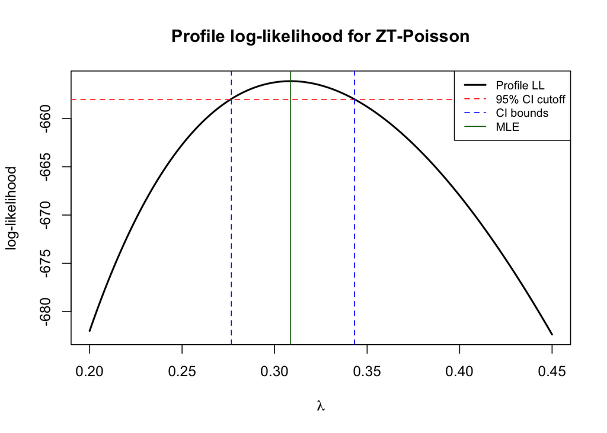

```r
lambda_grid <- seq(0.20, 0.45, length.out = 200)
ll_vals <- sapply(lambda_grid, function(l) ll(l, x))
ll_max <- ll(coef_mle, x)

## 95% CI via likelihood ratio
cutoff <- ll_max - qchisq(0.95, 1) / 2
ci_idx <- which(ll_vals >= cutoff)
ci_lower <- lambda_grid[min(ci_idx)]
ci_upper <- lambda_grid[max(ci_idx)]

plot(lambda_grid, ll_vals, type = "l", lwd = 2,
     xlab = expression(lambda), ylab = "log-likelihood",
     main = "Profile log-likelihood for ZT-Poisson")
abline(h = cutoff, col = "red", lty = 2)
abline(v = c(ci_lower, ci_upper), col = "blue", lty = 2)
abline(v = coef_mle, col = "darkgreen", lty = 1)
legend("topright",
       legend = c("Profile LL", "95% CI cutoff", "CI bounds", "MLE"),
       col = c("black", "red", "blue", "darkgreen"),
       lty = c(1, 2, 2, 1), lwd = c(2, 1, 1, 1), cex = 0.8)
```

```r
cat("Profile likelihood 95% CI: [", ci_lower, ",", ci_upper, "]\n")
```

```
Profile likelihood 95% CI: [ 0.2766332 , 0.3432161 ]
```

**Python**

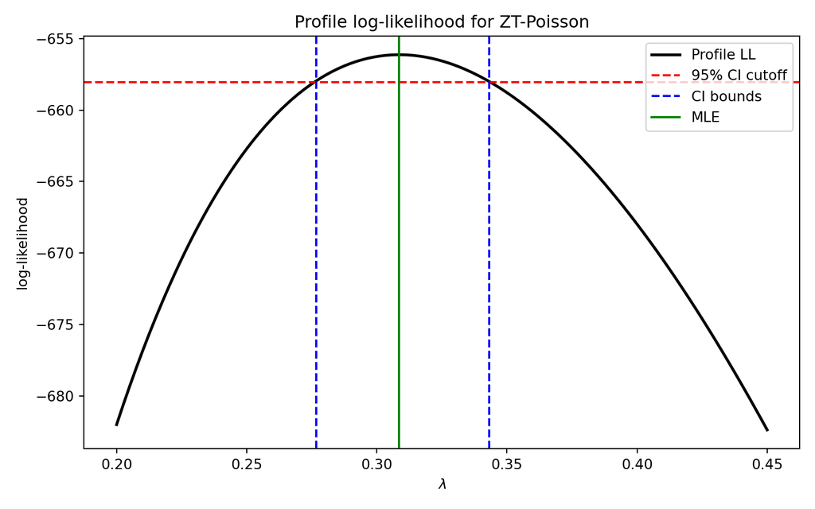

```python
import matplotlib
matplotlib.use('Agg')
import matplotlib.pyplot as plt

lambda_grid = np.linspace(0.20, 0.45, 200)
ll_func = lambda l: np.sum(x) * np.log(l) - len(x) * np.log(np.exp(l) - 1)
ll_vals = np.array([ll_func(l) for l in lambda_grid])
ll_max = ll_func(lambda_mle)

## 95% CI via likelihood ratio
cutoff = ll_max - st.chi2.ppf(0.95, 1) / 2
ci_idx = np.where(ll_vals >= cutoff)[0]
ci_lower = lambda_grid[ci_idx[0]]
ci_upper = lambda_grid[ci_idx[-1]]

plt.figure(figsize=(8, 5))
plt.plot(lambda_grid, ll_vals, 'k-', lw=2, label='Profile LL')
plt.axhline(y=cutoff, color='r', linestyle='--', label='95% CI cutoff')
plt.axvline(x=ci_lower, color='b', linestyle='--', label='CI bounds')
plt.axvline(x=ci_upper, color='b', linestyle='--')
plt.axvline(x=lambda_mle, color='green', linestyle='-', label='MLE')
plt.xlabel(r'$\lambda$')
plt.ylabel('log-likelihood')
plt.title('Profile log-likelihood for ZT-Poisson')
plt.legend()
plt.tight_layout()
plt.show()
```

```python
print(f"Profile likelihood 95% CI: [{ci_lower:.4f}, {ci_upper:.4f}]")
```

```
Profile likelihood 95% CI: [0.2766, 0.3432]
```

**Julia**

```julia
lambda_grid = range(0.20, 0.45, length=200)
```

```
0.2:0.001256281407035176:0.45
```

```julia
ll_func(l) = sum(x) * log(l) - length(x) * log(exp(l) - 1)
```

```
ll_func (generic function with 1 method)
```

```julia
ll_vals = [ll_func(l) for l in lambda_grid]
```

```
200-element Vector{Float64}:
 -682.0108528439318
 -681.3213808410969
 -680.6440401610216
 -679.9786838008063
 -679.325167467995
 -678.6833495143492
 -678.0530908716182
 -677.4342549892567
 -676.8267077740197
 -676.2303175313423
    ⋮
 -679.1241562923767
 -679.5218051953818
 -679.9221717887783
 -680.325242036791
 -680.7310020225445
 -681.1394379467158
 -681.5505361262176
 -681.96428299289
 -682.3806650922184
```

```julia
ll_max_val = ll_func(lambda_mle)
```

```
-656.1294299023264
```

```julia
## 95% CI via likelihood ratio
cutoff = ll_max_val - quantile(Chisq(1), 0.95) / 2
```

```
-658.0501593126734
```

```julia
ci_idx = findall(ll_vals .>= cutoff)
```

```
54-element Vector{Int64}:
  62
  63
  64
  65
  66
  67
  68
  69
  70
  71
   ⋮
 107
 108
 109
 110
 111
 112
 113
 114
 115
```

```julia
ci_lower = lambda_grid[first(ci_idx)]
```

```
0.2766331658291457
```

```julia
ci_upper = lambda_grid[last(ci_idx)]
```

```
0.34321608040201007
```

```julia
println("Profile likelihood 95% CI: [", round(ci_lower, digits=4),
        ", ", round(ci_upper, digits=4), "]")
```

```
Profile likelihood 95% CI: [0.2766, 0.3432]
```

### 3.5 QMLE (Quasi-MLE)

Quasi-maximum likelihood only requires specifying the mean-variance relationship rather than the full distribution. For the zero-truncated Poisson, we solve the quasi-score equation using the mean function $\mu(\lambda) = \lambda / (1 - e^{-\lambda})$ and variance function $V(\mu) = \mu$ (Poisson-like).

**R**

```r
## Quasi-score: sum of (x_i - mu(lambda)) / V(mu(lambda)) * mu'(lambda) = 0
mu_zt <- function(lambda) lambda / (1 - exp(-lambda))
mu_zt_deriv <- function(lambda) {
  e <- exp(-lambda)
  (1 - e - lambda * e) / (1 - e)^2
}

quasi_score <- function(lambda) {
  mu <- mu_zt(lambda)
  dmu <- mu_zt_deriv(lambda)
  sum((x - mu) / mu * dmu)
}

## uniroot: Brent's method to solve quasi-score equation
res_qmle <- uniroot(quasi_score, lower = 0.01, upper = 5)
lambda_qmle <- res_qmle$root

## Sandwich SE
mu_hat <- mu_zt(lambda_qmle)
dmu_hat <- mu_zt_deriv(lambda_qmle)
## bread: -sum(dmu^2 / V(mu))
bread <- sum(dmu_hat^2 / mu_hat)
## meat: sum((x - mu)^2 / V(mu)^2 * dmu^2)
meat <- sum((x - mu_hat)^2 / mu_hat^2 * dmu_hat^2)
se_qmle <- sqrt(meat / bread^2)

cat("QMLE: lambda =", lambda_qmle, ", Sandwich SE =", se_qmle, "\n")
```

```
QMLE: lambda = 0.3086173 , Sandwich SE = 38.02958
```

**Python**

```python
def mu_zt(lam):
    return lam / (1 - np.exp(-lam))

def mu_zt_deriv(lam):
    e = np.exp(-lam)
    return (1 - e - lam * e) / (1 - e)**2

def quasi_score(lam):
    mu = mu_zt(lam)
    dmu = mu_zt_deriv(lam)
    return np.sum((x - mu) / mu * dmu)

## fsolve: hybrid Powell method to solve quasi-score equation
res_qmle = fsolve(quasi_score, x0=0.5, full_output=True)
lambda_qmle = res_qmle[0][0]

## Sandwich SE
mu_hat = mu_zt(lambda_qmle)
dmu_hat = mu_zt_deriv(lambda_qmle)
bread = np.sum(dmu_hat**2 / mu_hat)
meat = np.sum((x - mu_hat)**2 / mu_hat**2 * dmu_hat**2)
se_qmle = np.sqrt(meat / bread**2)

print(f"QMLE: lambda = {lambda_qmle:.6f}, Sandwich SE = {se_qmle:.5f}")
```

```
QMLE: lambda = 0.308619, Sandwich SE = 38.02956
```

**Julia**

```julia
function mu_zt(lam)
    return lam / (1 - exp(-lam))
end
```

```
mu_zt (generic function with 1 method)
```

```julia
function mu_zt_deriv(lam)
    e = exp(-lam)
    return (1 - e - lam * e) / (1 - e)^2
end
```

```
mu_zt_deriv (generic function with 1 method)
```

```julia
function quasi_score(lam)
    mu = mu_zt(lam)
    dmu = mu_zt_deriv(lam)
    return sum((x .- mu) ./ mu .* dmu)
end
```

```
quasi_score (generic function with 1 method)
```

```julia
## find_zero: secant method to solve quasi-score equation
lambda_qmle = find_zero(quasi_score, 0.5)
```

```
0.30861895118866944
```

```julia
## Sandwich SE
mu_hat = mu_zt(lambda_qmle)
```

```
1.1622340425531918
```

```julia
dmu_hat = mu_zt_deriv(lambda_qmle)
```

```
0.5512737421888985
```

```julia
bread = sum(dmu_hat^2 / mu_hat)
```

```
0.26148153272067265
```

```julia
meat = sum((x .- mu_hat).^2 ./ mu_hat^2 .* dmu_hat^2)
```

```
98.88369934985269
```

```julia
se_qmle = sqrt(meat / bread^2)
```

```
38.02956263340116
```

```julia
println("QMLE: lambda = ", round(lambda_qmle, digits=6),
        ", Sandwich SE = ", round(se_qmle, digits=5))
```

```
QMLE: lambda = 0.308619, Sandwich SE = 38.02956
```

### 3.6 Summary

**R**

```r
results <- data.frame(
  Method = c("MLE", "GMM", "EM", "Profile LR", "QMLE"),
  Lambda = c(coef_mle, res_gmm$root, res_em$lambda, coef_mle, lambda_qmle),
  SE = c(se_mle, NA, NA, NA, se_qmle),
  CI_lower = c(coef_mle - 1.96 * se_mle, NA, NA, ci_lower,
               lambda_qmle - 1.96 * se_qmle),
  CI_upper = c(coef_mle + 1.96 * se_mle, NA, NA, ci_upper,
               lambda_qmle + 1.96 * se_qmle)
)
results
```

```
      Method    Lambda          SE    CI_lower   CI_upper
1        MLE 0.3086190  0.01725073   0.2748075  0.3424304
2        GMM 0.3086183          NA          NA         NA
3         EM 0.3086190          NA          NA         NA
4 Profile LR 0.3086190          NA   0.2766332  0.3432161
5       QMLE 0.3086173 38.02958137 -74.2293622 74.8465968
```

**Python**

```python
results = pd.DataFrame({
    "Method": ["MLE", "GMM", "EM", "Profile LR", "QMLE"],
    "Lambda": [lambda_mle, lambda_gmm, res_em["lambda"], lambda_mle, lambda_qmle],
    "SE": [se_mle, np.nan, np.nan, np.nan, se_qmle],
    "CI_lower": [lambda_mle - 1.96 * se_mle, np.nan, np.nan, ci_lower,
                 lambda_qmle - 1.96 * se_qmle],
    "CI_upper": [lambda_mle + 1.96 * se_mle, np.nan, np.nan, ci_upper,
                 lambda_qmle + 1.96 * se_qmle]
})
results.round(6)
```

```
       Method    Lambda         SE   CI_lower   CI_upper
0         MLE  0.308594   0.017255   0.274774   0.342414
1         GMM  0.308619        NaN        NaN        NaN
2          EM  0.308619        NaN        NaN        NaN
3  Profile LR  0.308594        NaN   0.276633   0.343216
4        QMLE  0.308619  38.029563 -74.229324  74.846562
```

**Julia**

```julia
DataFrame(
    Method = ["MLE", "GMM", "EM", "Profile LR", "QMLE"],
    Lambda = round.([lambda_mle, lambda_gmm, res_em.lambda, lambda_mle, lambda_qmle], digits=6),
    Note = ["Full distribution", "1 moment condition", "Latent zeros", "LR-based CI", "Sandwich SE"]
)
```

```
5×3 DataFrame
 Row │ Method      Lambda    Note
     │ String      Float64   String
─────┼──────────────────────────────────────────
   1 │ MLE         0.308619  Full distribution
   2 │ GMM         0.308619  1 moment condition
   3 │ EM          0.308619  Latent zeros
   4 │ Profile LR  0.308619  LR-based CI
   5 │ QMLE        0.308619  Sandwich SE
```